# Comparing Random Forest Approaches to Class-Imbalanced Payment Fraud Detection

Author

Nicholas Pargoff and Andrew Mattson (Advisor: Dr. Cohen)

Published

October 19, 2026

Slides: slides.html ( Go to `slides.qmd` to edit)

## Introduction

Payment fraud is becoming more prevalent with the current climate of e-commerce and the development of different payment methods. In July 2023, the Federal Reserve launched the FedNow Service, which allows banks and credit unions of any size to send instant payments at any time of day and every day of the year (Federal Reserve Financial Services 2023). As real-time payment adoption increases, fraud detection models must flag suspicious transactions as they happen. This increases the need for more robust ways to identify transaction fraud. Random forest is commonly used to address this problem. Current research focuses on handling the unbalanced nature of fraudulent transactions. In this paper we test some of the common random forest models against the original algorithm to find which model has greater fraud detection performance.

Literature Review

Random Forest (RF) is a widely adopted machine learning method because of its computational efficiency and versatility (Scornet and Hooker 2026; Salman et al. 2024). It uses random samples of data to build multiple decision trees, and because the trees are not highly correlated the risk of overfitting is relatively low (Salman et al. 2024). RF was initially created to run classification and regression tests but has expanded into other domains like survival analysis and quantile regression. The subsampling structure allows the uncertainty of its predictions to be quantified (Scornet and Hooker 2026). RF’s main limitation is prediction speed. It can train quickly but can be slow when needed for real-time decisions (Salman et al. 2024).

RF has proven effective for credit card fraud detection (Jebaseeli et al. 2020; Borketey 2024; Salunke et al. 2025). Borketey (2024) compared it with logistic regression, linear discriminant analysis, k-nearest neighbors, and classification trees on a dataset with 0.17% fraudulent transactions with RF detecting about 71% of those transactions. Some studies used RF that did not adjust for class imbalance and the authors judged RF mainly on overall predictions (Jebaseeli et al. 2020). RF has limitations like degrading when the scale of the dataset increases (Xuan et al. 2018). Fraud changes over time and data collection is different by region making it difficult to generalize (Borketey 2024).

Using accuracy as a metric is not the best way to measure performance of this method when fraudulent transactions are rare. A model can have a very high accuracy score while missing most of the fraudulent transactions. For this reason, several studies relied on precision, recall, F1, and area-under-the-curve measures (Galar et al. 2012; Borketey 2024; Wijaya et al. 2024; Aburbeian and Ashqar 2023).

A common way to deal with data imbalance is to pair RF with SMOTE (Bhagat and Patil 2015; Aburbeian and Ashqar 2023; Zhang 2024). This combination has improved the minority-class detection outside fraud. Bhagat and Patil (2015) applied SMOTE after splitting the multi-class problem with One-vs-All and One-vs-One methods and Zhang (2024) combined SMOTE with tree pruning and Z-score normalization and reached 98.03% accuracy and 100% recall. The results do support the general approach of pairing SMOTE with RF; however, this may not directly transfer over to fraud detection. SMOTE was found to not always be the most effective option. Random oversampling with XGBoost achieved the highest F1-score, 92.43% and the authors concluded that random oversampling, or undersampling with NCR, gave the best results (Wijaya et al. 2024).

Some methods change how the ensemble samples the data. Galar et al. (2012) reviewed 22 ensemble variants across four families, using a single C4.5 decision tree as the base classifier with AUC for evaluation. The most complex approaches did not always have the best performance. SMOTEBagging, RUSBoost, and UnderBagging were the most robust. RUSBoost provided good performance and was the least complex. Gu et al. (2022) proposed that an improper sampling strategy can negatively impact model performance, increase complexity, and cause overfitting. The study also found that DCI-ISSA-RF, which combines DCI oversampling with ISSA hyperparameter optimization, outperformed undersampling, most cost-sensitive methods and baseline RF. However, DCI-ISSA-RF ran longer on large credit card datasets which relates to the speed concern raised by Salman et al. (2024).

These studies find that RF is an acceptable choice for fraud detection. They also provide different techniques for handling class imbalance. The results are difficult to compare because the studies had significant variations like different datasets and performance metrics. Some of the studies did not use cross validation (Wijaya et al. 2024) while others used overall accuracy (Salunke et al. 2025) for their results making it unclear how each imbalance technique improves RF itself. This study attempts to address the previous study variations by using a baseline RF and only changing the imbalance treatment. Each approach will be evaluated on fraud-class precision, recall, F1, and AUC-PR.

## Methodology

A Random Forest combines many decision trees to make predictions (Scornet and Hooker 2026). Each tree uses a random sample of the training data and considers a random subset of features at each split. Combining the trees generally produces more reliable predictions and reduces overfitting compared with a single decision tree. This will use the Kaggle dataset (greatcool 2026) with 10,000 synthetic transactions.

1. Create random samples. Draw a training sample for each tree with replacement, meaning some observations may appear more than once.

2. Build the trees. At each split, consider a random subset of features and choose the best split from those features.

3. Combine predictions. For classification, use the majority vote across trees.

4. Evaluate and tune. Use AUC-PR with cross-validation to adjust model settings, then assess the final model on the testing set.

We will be comparing four different ways to handle the imbalanced data in the random forest model (Galar et al. 2012). The four models’ data will be stratified 70/30 between training and testing data:

· Baseline: This will train a random forest without adjusting the data for the class imbalance.

· SMOTE: This method creates synthetic data points for the fraudulent transactions then uses that data to train the random forest model (Galar et al. 2012). This will be applied to the training data within each cross-validation fold. Data points are generated between a fraud case and one of its nearest fraud neighbors.

· Balanced Random Forest: This method will train each tree on a balanced sample, meaning the model will under sample the non-fraudulent transactions to match the fraudulent transactions. As a result, each tree has a different subset of non-fraudulent transactions.

· Class Weighting: This method will give the minority class greater weight so that errors predicting fraudulent transactions will penalize the model more, allowing us to train the model without changing the number of observations.

## Analysis and Results

### Data Exploration and Visualization

Our dataset contains 10,000 synthetic financial transactions from August 2025 to August 2026 with 2,142 unique users. The data was obtained from Kaggle (greatcool 2026). Of the 10,000 transactions only 126 or 1.26% of them are fraudulent. There are no missing values or duplicate transactions. The dataset contains 11 variables including the target variable “is_fraud”. The 10 other variables are:

Transaction_id: An identification variable that identifies each unique transaction

Timestamp: A datetime variable that has the time of each transaction

User_id: this is an identification variable for each user

Account_type: this is a categorical variable that lists the type of account that was used in the transaction such as savings or checking account

Category: A categorical variable that describes what type of product was purchased such as electronics or groceries

Amount: A numeric variable that shows the value of the transaction in US dollars

Currency: A category variable that shows what kind of currency was used for example USD

Payment_method: A categorical variable that names what was used for the payment for example debit card or credit card

Device_type: categorical variable the names the type of machine that was used such as a POS machine or ATM

Risk_score: A numeric variable that is between 0 to 100 that represents the predicted risk of the transaction with 0 being the lowest risk and 100 being the highest risk.

Is_fraud: The target variable that determines if a transaction was fraudulent or not with a 1 being fraud and 0 representing a non-fraud transaction.

```r
# loading packages
library(tidyverse)
library(gtsummary)
library(readr)
library(dplyr)
library(ggplot2)
```

```python
import pandas as pd
```

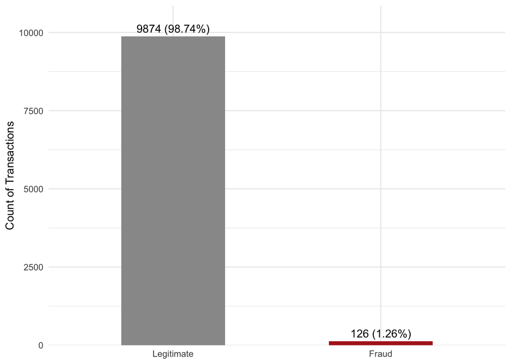

```r
# Load data
fraud_df <- read_csv("synthetic_financial_transactions.csv") %>%
  mutate(is_fraud = factor(is_fraud, levels = c(0, 1),
                           labels = c("Legitimate", "Fraud")))

# Numeric copy of the target for fraud rate summaries
fraud_data <- fraud_df %>% mutate(fraud_num = as.numeric(is_fraud == "Fraud"))

fraud_summary <- fraud_data %>%
  count(fraud_num, name = "count") %>%
  mutate(percent = count / sum(count) * 100)

ggplot(fraud_summary, aes(x = factor(fraud_num), y = count, fill = factor(fraud_num))) +
  geom_col(width = 0.5) +
  geom_text(aes(label = paste0(count, " (", round(percent, 2), "%)")), vjust = -0.5) +
  scale_x_discrete(labels = c("0" = "Legitimate", "1" = "Fraud")) +
  scale_fill_manual(values = c("0" = "gray60", "1" = "firebrick")) +
  scale_y_continuous(expand = expansion(mult = c(0, 0.1))) +
  labs(x = NULL, y = "Count of Transactions") +
  theme_minimal() +
  theme(legend.position = "none")
```

*Figure 1. Class distribution of legitimate and fraudulent transactions*

```r
fraud_df %>%
  select(is_fraud, amount, risk_score, account_type, category,
         payment_method, device_type) %>%
  tbl_summary(by = is_fraud,
              statistic = all_continuous() ~ "{median} ({p25}, {p75})",
              label = list(amount ~ "Transaction amount (USD)",
                           risk_score ~ "Risk score",
                           account_type ~ "Account type",
                           category ~ "Transaction category",
                           payment_method ~ "Payment method",
                           device_type ~ "Device type")) %>%
  add_overall() %>%
  add_p() %>%
  bold_labels() %>%
  modify_caption("**Table 1.** Descriptive statistics by transaction class")
```

**Table 1.** Descriptive statistics by transaction class

| **Characteristic** | **Overall** N = 10,000<sup>1</sup> | **Legitimate** N = 9,874<sup>1</sup> | **Fraud** N = 126<sup>1</sup> | **p-value**<sup>2</sup> |
| --- | --- | --- | --- | --- |
| Transaction amount (USD) | 27 (13, 58) | 27 (13, 58) | 25 (12, 55) | 0.7 |
| Risk score | 27 (16, 39) | 27 (16, 39) | 33 (19, 59) | <0.001 |
| Account type |  |  |  | 0.4 |
| Checking | 4,555 (46%) | 4,505 (46%) | 50 (40%) |  |
| Credit Card | 1,453 (15%) | 1,433 (15%) | 20 (16%) |  |
| Savings | 3,992 (40%) | 3,936 (40%) | 56 (44%) |  |
| Transaction category |  |  |  | 0.7 |
| Dining | 1,944 (19%) | 1,925 (19%) | 19 (15%) |  |
| Electronics | 1,018 (10%) | 1,003 (10%) | 15 (12%) |  |
| Entertainment | 962 (9.6%) | 952 (9.6%) | 10 (7.9%) |  |
| Groceries | 2,515 (25%) | 2,481 (25%) | 34 (27%) |  |
| Healthcare | 490 (4.9%) | 486 (4.9%) | 4 (3.2%) |  |
| Online Transfer | 1,029 (10%) | 1,013 (10%) | 16 (13%) |  |
| Travel | 822 (8.2%) | 809 (8.2%) | 13 (10%) |  |
| Utilities | 1,220 (12%) | 1,205 (12%) | 15 (12%) |  |
| Payment method |  |  |  | 0.8 |
| Bank Transfer | 977 (9.8%) | 966 (9.8%) | 11 (8.7%) |  |
| Credit Card | 3,602 (36%) | 3,555 (36%) | 47 (37%) |  |
| Debit Card | 3,451 (35%) | 3,404 (34%) | 47 (37%) |  |
| UPI | 1,970 (20%) | 1,949 (20%) | 21 (17%) |  |
| Device type |  |  |  | 0.9 |
| ATM | 965 (9.7%) | 953 (9.7%) | 12 (9.5%) |  |
| Desktop | 2,529 (25%) | 2,501 (25%) | 28 (22%) |  |
| Mobile | 5,472 (55%) | 5,399 (55%) | 73 (58%) |  |
| POS Terminal | 1,034 (10%) | 1,021 (10%) | 13 (10%) |  |

<sup>1</sup> Median (Q1, Q3); n (%)  
<sup>2</sup> Wilcoxon rank sum test; Pearson’s Chi-squared test

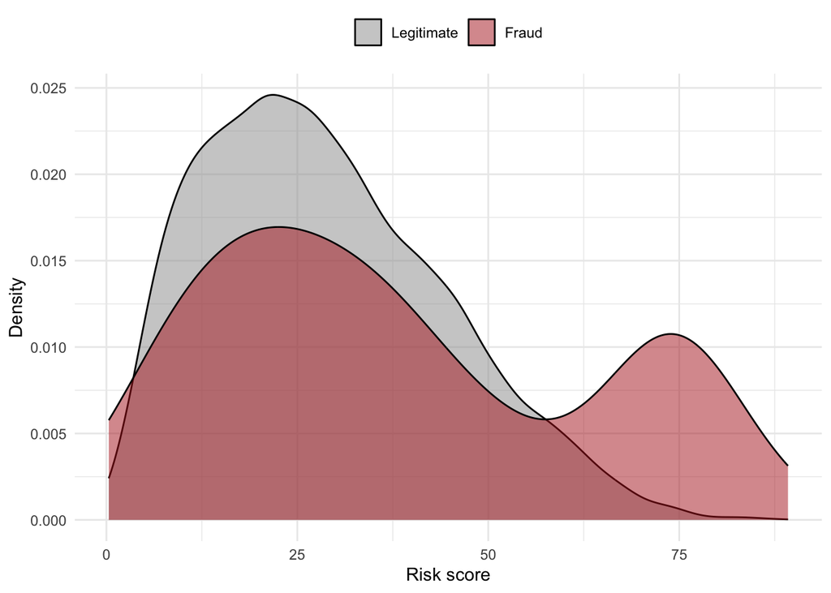

```r
fraud_df %>%
  ggplot(aes(risk_score, fill = is_fraud)) +
  geom_density(alpha = 0.5) +
  scale_fill_manual(values = c("Legitimate" = "gray60", "Fraud" = "firebrick")) +
  labs(x = "Risk score", y = "Density", fill = NULL) +
  theme_minimal() +
  theme(legend.position = "top")
```

*Figure 2. Risk score distribution by transaction class*

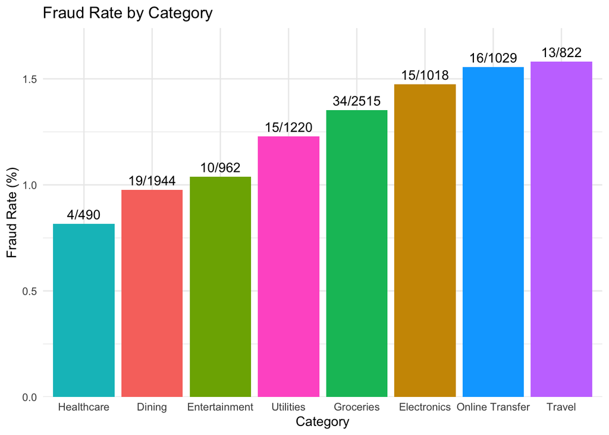

```r
# Plot 2: fraud rate by category
category_fraud <- fraud_data %>%
  group_by(category) %>%
  summarise(total_transactions = n(),
            fraud_count = sum(fraud_num),
            fraud_rate = mean(fraud_num) * 100,
            .groups = "drop")

ggplot(category_fraud, aes(x = reorder(category, fraud_rate), y = fraud_rate, fill = category)) +
  geom_col() +
  geom_text(aes(label = paste0(fraud_count, "/", total_transactions)), vjust = -0.5) +
  scale_y_continuous(expand = expansion(mult = c(0, 0.1))) +
  labs(title = "Fraud Rate by Category", x = "Category", y = "Fraud Rate (%)") +
  theme_minimal() +
  theme(legend.position = "none")
```

*Figure 3. Fraud rate by transaction category*

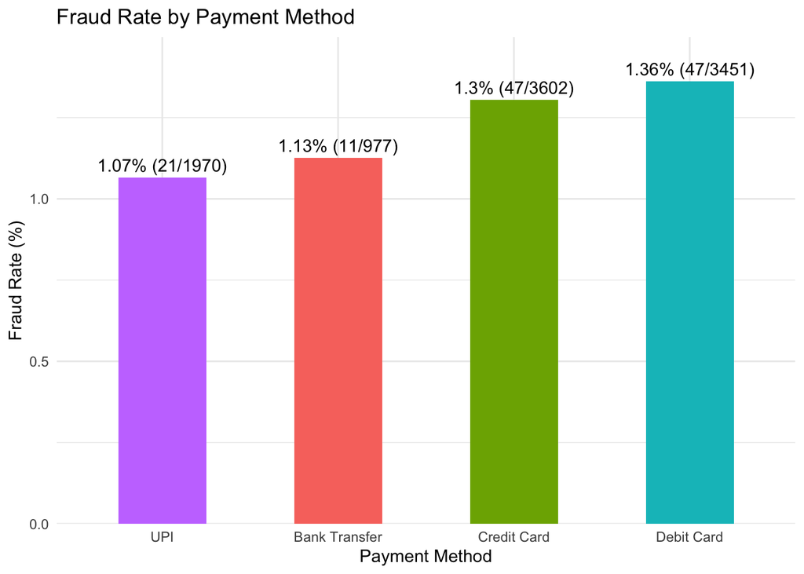

```r
# Plot 3: fraud rate by payment method
payment_fraud_pct <- fraud_data %>%
  group_by(payment_method) %>%
  summarise(total_transactions = n(),
            fraud_count = sum(fraud_num),
            fraud_rate = mean(fraud_num) * 100,
            .groups = "drop")

ggplot(payment_fraud_pct, aes(x = reorder(payment_method, fraud_rate), y = fraud_rate, fill = payment_method)) +
  geom_col(width = 0.5) +
  geom_text(aes(label = paste0(round(fraud_rate, 2), "% (", fraud_count, "/", total_transactions, ")")),
            vjust = -0.5) +
  scale_y_continuous(expand = expansion(mult = c(0, 0.1))) +
  labs(title = "Fraud Rate by Payment Method", x = "Payment Method", y = "Fraud Rate (%)") +
  theme_minimal() +
  theme(legend.position = "none")
```

*Figure 4. Fraud rate by payment method*

Table 1 compares legitimate and fraudulent transactions. Risk score was the only variable that had a significant difference between the groups with a p-value <0.001. Transaction amount, account type, merchant category, payment method, and device type showed no significant difference. Model performance will likely depend on the risk score.

The Fraudulent vs Non-Fraudulent Transactions plot shows the data imbalance, with only 1.26% of the 10,000 transactions marked as fraudulent. The Fraud Rate by Category and Fraud Rate by Payment Method plots indicate that Travel had the highest fraud rate at 1.58% and debit card had the highest by payment method at 1.36%; however, the differences between the groups are small and were not statistically significant per Table 1. The small number of fraud cases in each group makes these rates unreliable.

## References

Aburbeian, AlsharifHasan Mohamad, and Huthaifa I. Ashqar. 2023. “Credit Card Fraud Detection Using Enhanced Random Forest Classifier for Imbalanced Data.” *Proceedings of the 2023 International Conference on Advances in Computing Research (ACR’23)* (Cham), Lecture notes in networks and systems, vol. 700: 605–16. https://doi.org/10.1007/978-3-031-33743-7_48.

Bhagat, Reshma C., and Sachin S. Patil. 2015. “Enhanced SMOTE Algorithm for Classification of Imbalanced Big-Data Using Random Forest.” *2015 IEEE International Advance Computing Conference (IACC)*, 403–8. https://doi.org/10.1109/IADCC.2015.7154739.

Borketey, Benjamin. 2024. “Real-Time Fraud Detection Using Machine Learning.” *Journal of Data Analysis and Information Processing* 12: 189–209. https://doi.org/10.4236/jdaip.2024.122011.

Federal Reserve Financial Services. 2023. *The FedNow Service for Instant Payments Is Live*. https://frbservices.org/news/fed360/issues/080123/fednow-service-instant-payments.

Galar, Mikel, Alberto Fernández, Edurne Barrenechea, Humberto Bustince, and Francisco Herrera. 2012. “A Review on Ensembles for the Class Imbalance Problem: Bagging-, Boosting-, and Hybrid-Based Approaches.” *IEEE Transactions on Systems, Man, and Cybernetics, Part C (Applications and Reviews)* 42 (4): 463–84. https://doi.org/10.1109/TSMCC.2011.2161285.

greatcool. 2026. *Financial Transactions and Fraud Detection Dataset*. Kaggle. https://www.kaggle.com/datasets/greatcool/financial-transactions-and-fraud-detection-dataset.

Gu, Qinghua, Jingni Tian, Xuexian Li, and Song Jiang. 2022. “A Novel Random Forest Integrated Model for Imbalanced Data Classification Problem.” *Knowledge-Based Systems* 250: 109050. https://doi.org/10.1016/j.knosys.2022.109050.

Jebaseeli, T. Jemima, R. Venkatesan, and K. Ramalakshmi. 2020. “Fraud Detection for Credit Card Transactions Using Random Forest Algorithm.” In *Intelligence in Big Data Technologies: Beyond the Hype. Proceedings of ICBDCC 2019*, edited by J. Dinesh Peter, Steven L. Fernandes, and Amir H. Alavi. Springer. https://doi.org/10.1007/978-981-15-5285-4_18.

Salman, Hasan Ahmed, Ali Kalakech, and Amani Steiti. 2024. “Random Forest Algorithm Overview.” *Babylonian Journal of Machine Learning* 2024: 69–79. https://doi.org/10.58496/BJML/2024/007.

Salunke, Yugal, Saroj Phalke, Manoj Madavi, Praali Kumre, and Grishma Bobhate. 2025. “Fraud Detection: A Hybrid Approach with Logistic Regression, Decision Tree, and Random Forest.” *Cureus Journal of Computer Science* 2. https://doi.org/10.7759/s44389-024-02350-5.

Scornet, Erwan, and Giles Hooker. 2026. “Theory of Random Forests.” *Annual Review of Statistics and Its Application* 13: 99–121. https://doi.org/10.1146/annurev-statistics-112723-034707.

Wijaya, Michael Geraldin, Muhammad Faza Pinaringgi, Alfi Yusrotis Zakiyyah, and Meiliana. 2024. “Comparative Analysis of Machine Learning Algorithms and Data Balancing Techniques for Credit Card Fraud Detection.” *Procedia Computer Science* 245: 677–88. https://doi.org/10.1016/j.procs.2024.10.294.

Xuan, Shiyang, Guanjun Liu, Zhenchuan Li, Lutao Zheng, Shuo Wang, and Changjun Jiang. 2018. “Random Forest for Credit Card Fraud Detection.” *2018 IEEE 15th International Conference on Networking, Sensing and Control (ICNSC)*, 1–6. https://doi.org/10.1109/ICNSC.2018.8361343.

Zhang, Jianhui. 2024. “Impact of an Improved Random Forest-Based Financial Management Model on the Effectiveness of Corporate Sustainability Decisions.” *Systems and Soft Computing* 6: 200102. https://doi.org/10.1016/j.sasc.2024.200102.